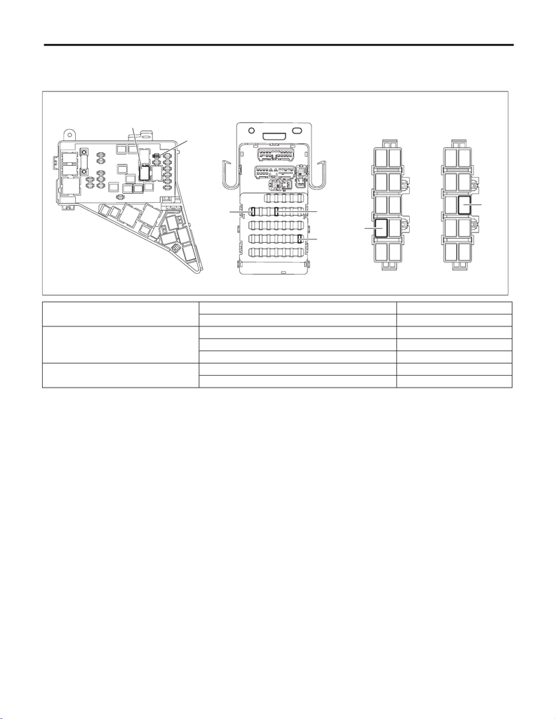

GW-7

Relay and Fuse

GLASS/WINDOWS/MIRRORS

2. Relay and Fuse

A: LOCATION

NOTE:

For other related fuses, refer to the wiring diagram. <Ref. to WI-28, Power Supply Circuit.>

Main fuse box

Rear defogger relay (A)

Fuse 25 A (rear defogger) (B)

Relay & fuse box

Fuse 7.5 A (remote control mirror) (C)

Fuse 15 A (wiper deicer) (D)

Fuse 7.5 A (power window) (E)

Relay holder

Power window relay (F)

Wiper deicer relay (G)

GW-01018

(C)

(D)

(B)

(A)

(E)

(F)

(G)

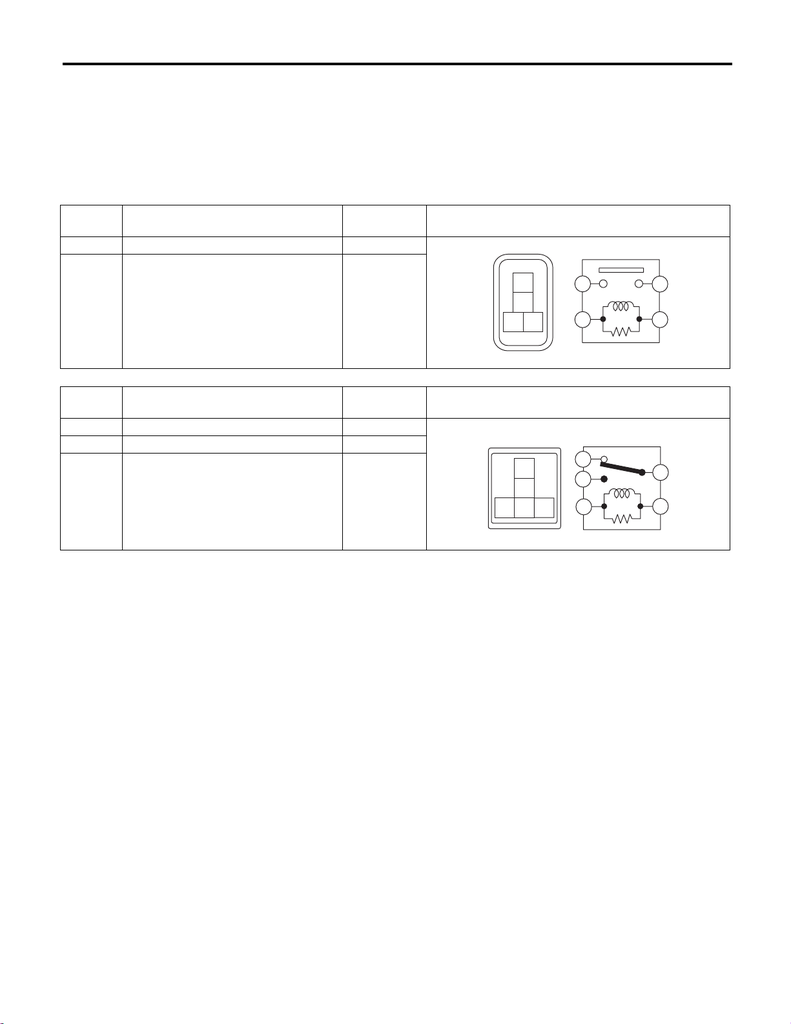

GW-8

Relay and Fuse

GLASS/WINDOWS/MIRRORS

B: INSPECTION

1. CHECK FUSE

1) Remove the fuse and check visually.

2) If the fuse is blown out, replace the fuse.

2. CHECK RELAY

1) Check the resistance between relay terminals.

2) Replace the relay if the inspection result is not within the standard value.

Terminal

No.

Inspection conditions Specification Circuit

1 — 2 Always 1 MΩ or more

1 — 2

Apply battery voltage between 4 — 3 ter-

minals.

Less than 1 Ω

Terminal

No.

Inspection conditions Specification Circuit

1 — 2 Always 1 MΩ or more

1 — 4 Always Less than 1 Ω

1 — 2

Apply battery voltage between 3 — 5 ter-

minals.

Less than 1 Ω

SR-00180

1

2

2

3 4

1

SL-01085

2

4

3

5

1

1

2

5